# Applications of Inference Frameworks: More Basics

## Models

- Comparing models will require covering a few more basics
  - Concepts of central tendency
  - Concepts of spread
  - Deviations & sums of squares
  - Introduction to confidence intervals

## Measures of central tendency (location)

The value around which the distribution is centered

1. Mean
2. Median
3. Mode (most common value)

## Mean

Sample (arithmetic) mean:

\[\bar{Y} = \frac{\sum^n_{i=1}Y_i}{n}\]

The term “mean” is preferred to “average”. The arithmetic mean is one kind of average, but there are others (as there are other types of means).

- One argument: “Average” is a statistic determined by an arithmetic procedure. “Mean” is a parameter.

## Median

The median is the central measurement of a sample (the 50th percentile and the 0.50 quantile). If \(n\) is even, then the median is the mean of the two middle observations.

```r
undulation_rate <- c(0.9, 1.2, 1.2, 1.3, 1.4, 1.4, 1.6, 2.0)
median(undulation_rate)
```

```
## [1] 1.35
```

## Mean vs. Median

Number of lateral plates (plates) in threespine sticklebacks (*Gasterosteus aculeatus*) with three different *Ectodysplasin* genotypes (mm, Mm, and MM).

[figure not shown]

## Mean vs. Median

```r
glimpse(SticklebackPlates)
```

```
## Rows: 344
## Columns: 2
## $ genotype <chr> "mm", "Mm", "Mm", "Mm", "mm", "mm", "Mm", "Mm", "Mm", "Mm", …
## $ plates   <dbl> 11, 63, 22, 10, 14, 11, 58, 36, 31, 61, 63, 8, 12, 11, 64, 6…
```

## Mean vs. Median

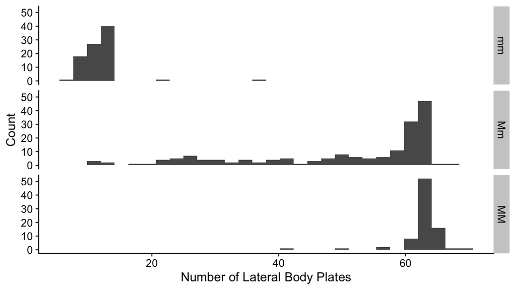

## Mean vs. Median

```r
SticklebackPlates %>% group_by(genotype) %>%
  summarize(mean_plate = mean(plates),
            median_plate = median(plates))
```

```
## # A tibble: 3 x 3
##   genotype mean_plate median_plate
##   <chr>         <dbl>        <dbl>
## 1 mm             11.7           11
## 2 Mm             50.4           59
## 3 MM             62.8           63
```

## Mean is sensitive to extreme values

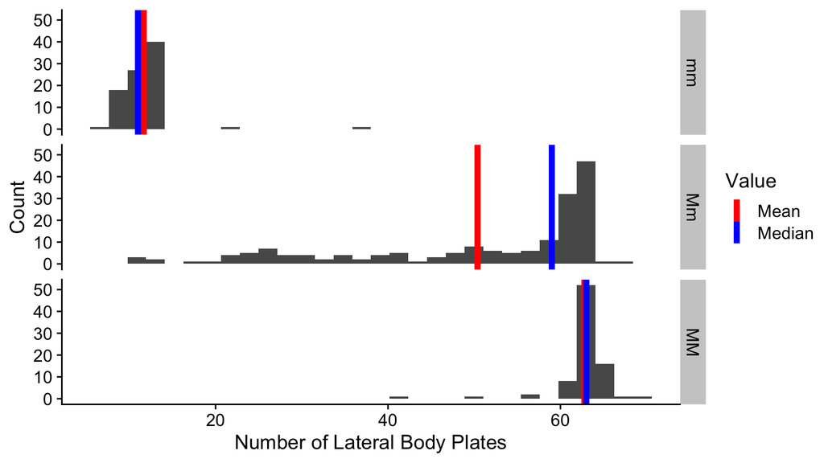

## When might you substitute the median for the mean?

### (As a measure of central tendency)

## Why don’t we always use the median?

## Measures of spread

- A measure of how much variation is present in a distribution around its center
- How widely scattered the observations are

## Percentiles and quantiles

The \(X\)th **percentile** of a sample is the value below which \(X\%\) of the observations lie. Percentiles are reported as percent.

**Quantile** = Percentile / 100%. The range of quantiles is \(0 \rightarrow 1\).

```r
xx <- rnorm(100000)
quantile(xx, 0.84)
```

```
##       84%
## 0.9869297
```

```r
quantile(xx, 0.975)
```

```
##    97.5%
## 1.949865
```

## Quartiles and interquartile range

*Quartiles*

- Divide a set of data into quarters
- Minimum, maximum, 25th and 75th percentiles

*Interquartile range*

- Difference between the first and third quartiles

## Boxplots

Different variations, but the most standard recipe is:

1. Median = center line
2. Box = IQR (25th to 75th percentiles)
3. Whiskers at 1.5 X 25th and 75th percentiles
4. Dots for anything outside 1.5 X 25th and 75th percentiles

## Boxplots

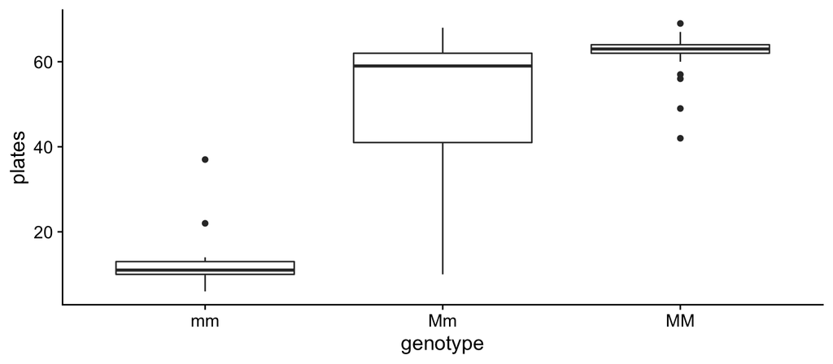

```r
ggplot(SticklebackPlates, aes(x = genotype, y = plates)) +
  geom_boxplot()
```

## Raw data as an alternative to boxplots

When the number of observations is small, just show the raw data as points.

```r
ggplot(SticklebackPlates, aes(x = genotype, y = plates)) +
  geom_point()
```

`x = genotype` maps the x position to the categorical variable genotype. `geom_point()` adds the points.

## Raw data as an alternative to boxplots

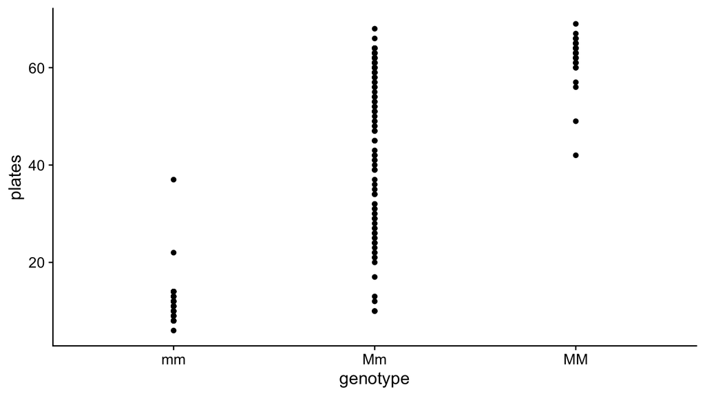

## Raw data as an alternative to boxplots

Add a little jitter on the x axis to keep from overplotting.

```r
ggplot(SticklebackPlates, aes(x = genotype, y = plates)) +
  geom_point(position = position_jitter(width = 0.2))
```

## Raw data as an alternative to boxplots

Add a little jitter on the x axis to keep from overplotting.

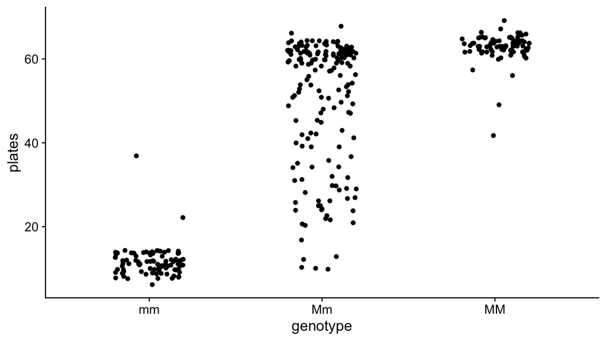

## Deviates

Lots of statistics have their basis in the deviation of an observation from a mean.

[figure not shown]

The \(i\)th deviate is the difference of that observation and the sample mean:

\[ \textrm{Deviate}_i = Y_i - \bar{Y} \]

We would like to have a single number to summarize the deviates for a sample.

## Sum of squares

Deviates are most often squared and summed:

\[ SS = \sum \left(Y_i - \bar{Y}\right)^2 \]

1. Why squared?
2. What does the sum of squares represent?

## Mean deviates

This is why we don’t use the mean absolute deviation:

[figure not shown]

Absolute value wouldn’t capture the greater variability in the right image.

## Sample variance

Sum of squares standardized by one minus the sample size (\(n - 1\)):

\[ s^2 = \frac{\sum \left(Y_i - \bar{Y}\right)^2}{n - 1} \]

- Mean squared deviation of the observations from the mean.
- Measures the dispersion of a distribution away from the sample mean.

## Sample standard deviation

\[ s = \sqrt{\frac{\sum \left(Y_i - \bar{Y}\right)^2}{n - 1}} \]

- Square root of the sample variance.
- Think of \(s\) as the “mean” for deviation.
- About 68% of the observations are \(\pm 1\) standard deviation from the mean.
- When sample size is not low, the sample variance (\(s^2\)) is an *unbiased estimator* of the population variance (\(\sigma^2\)), though the calculation is a little different (divide by \(n\) rather than \(n − 1\)) See [explanation of \(n\) vs. \(n-1\)](http://stats.stackexchange.com/q/3931/597)

## Standard error of the sample mean

\[SE_{\bar{Y}} = \frac{s}{\sqrt{n}}\]

Means are always reported with standard errors (or standard deviations).

- **Standard deviation** quantifies scatter — how much the values vary from one another and does not change predictably as you collect more data.
- **Standard error** of the mean quantifies how precisely you know the population mean. It takes into account both the value of \(s\) and the sample size. Always decreases with larger sample size.

## Standard error of the sample mean

```r
SEM <- function(x) {sd(x) / sqrt(length(x))}

SticklebackPlates %>%
  group_by(genotype) %>%
  summarise_all(SEM)
```

```
## # A tibble: 3 x 2
##   genotype plates
##   <chr>     <dbl>
## 1 mm        0.380
## 2 Mm        1.15
## 3 MM        0.377
```

## Raw data with summary stats

```r
ggplot(SticklebackPlates, aes(x = genotype, y = plates)) +
  geom_point(position = position_jitter(width = 0.2), alpha = 0.5) +
  stat_summary(fun.y = mean, geom = "point", size = 3, color = "red") +
  stat_summary(fun.data = mean_se, geom = "errorbar", width = 0.1,
               color = "red", size = 1)
```

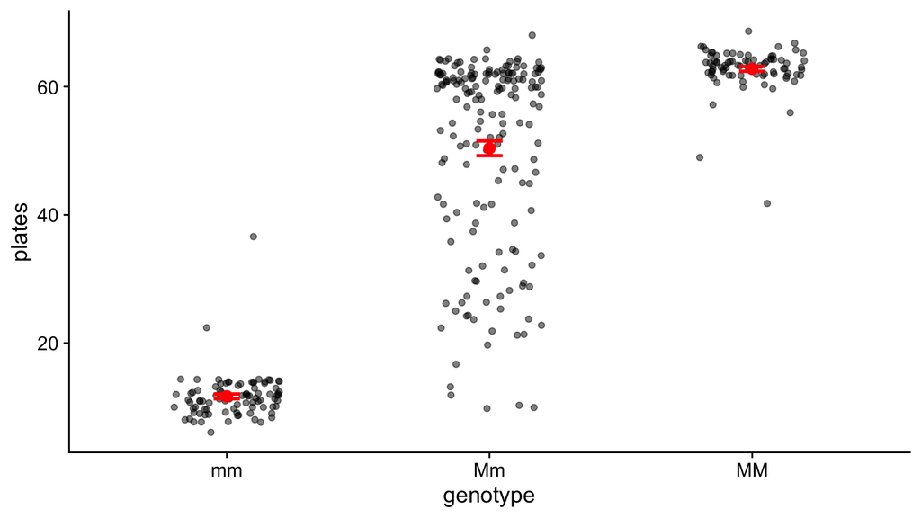

## Confidence intervals

> A confidence interval is a range that we expect, with some level of conﬁdence, to include the true value of a population parameter such as the mean. (Curran-Everett 2009)

Our calculation is based on our expectation from sampling the true population distribution repeatedly. Let’s try these:

- [Sampling](http://www.zoology.ubc.ca/~whitlock/kingfisher/SamplingNormal.htm)
- [Confidence Intervals](http://www.zoology.ubc.ca/~whitlock/kingfisher/CIMean.htm)

## Confidence intervals

The 95% confidence interval for a mean can be estimated by the sample mean ± 2 \(SE_{\bar{Y}}\).

- This is a reasonable approximation.
- We’ll cover the exact calculation (what you would use in press) later

## Confidence intervals

```r
y_bar <- mean(undulation_rate)
se_y <- sd(undulation_rate) / sqrt(length(undulation_rate))
lower <- y_bar - 2 * se_y
upper <- y_bar + 2 * se_y
```

We are 95% confident that the true mean lies between 1.15 and 1.6.

Mean undulation rate was 1.38 Hz (\(n\) = 8; 95% CI = 1.15 - 1.6 Hz).

## Coefficient of variation

Coefficient of variation represents the standard deviation as a percentage of the mean. Elephant mass has an inherently higher standard deviation than mouse mass.

\[ CV = 100\% \times \frac{s}{\bar{Y}} \]

- Can be used as a general indicator of the amount of variability in a sample.
- Can also be used to (cautiously) compare variables that are not measured in the same units (e.g., basal metabolic rate to ear area).

## Coefficient of variation

```r
CV <- 100 * sd(undulation_rate) / mean(undulation_rate)
CV
```

```
## [1] 23.56633
```

The coefficient of variation of undulation rate was 23.6%.

## References

Curran-Everett, D. 2009. Explorations in Statistics: Confidence Intervals. *Adv. Physiol. Educ.* 33:87–90.